# homework11

# Homework 11

Yi Chen, YC3356

## 1. Review the following case study, focusing on the model:

```r
# load the libraries
library(extraDistr)
library(ggplot2)
library(tidyr)
library(dplyr)
library(gridExtra)
library(rstan)
library(bayesplot)
library(loo)
rstan_options(auto_write = TRUE)
options(mc.cores = parallel::detectCores())
```

### a. Simulate fake data and check that the model recovers the parameters. Feel free to simplify the model as necessary.

```r
# first simulate the data which follow the generalized Pareto distribution
u <- 2
k <- 3
sigma <- 3

gpareto = function(n,u,sigma,k){
  y = c()
  for (i in 1:n){
      if (k != 0) {y = c(y,( u + (runif(n=1,min = 0,max = 1)^(-k) -1) * sigma / k))}
    else{y = c(y,(u - sigma*log(runif(n=1,min = 0,max = 1))))}
  }
  return(y)
}
n = 100
y_fake = gpareto(n=n,u=u,k=k,sigma=sigma)
yt<-append(seq(2,3,.01)*30,values = 10)
ds<-list(ymin=u, N=n, y=y_fake, Nt=length(yt), yt=yt)
```

```r
writeLines(readLines("gpareto.stan"))
```

```
## functions {
##   real gpareto_lpdf(vector y, real ymin, real k, real sigma) {
##     // generalised Pareto log pdf
##     int N = rows(y);
##     real inv_k = inv(k);
##     if (k<0 && max(y-ymin)/sigma > -inv_k)
##       reject("k<0 and max(y-ymin)/sigma > -1/k; found k, sigma =", k, sigma)
##     if (sigma<=0)
##       reject("sigma<=0; found sigma =", sigma)
##     if (fabs(k) > 1e-15)
##       return -(1+inv_k)*sum(log1p((y-ymin) * (k/sigma))) -N*log(sigma);
##     else
##       return -sum(y-ymin)/sigma -N*log(sigma); // limit k->0
##   }
##   real gpareto_cdf(vector y, real ymin, real k, real sigma) {
##     // generalised Pareto cdf
##     real inv_k = inv(k);
##     if (k<0 && max(y-ymin)/sigma > -inv_k)
##       reject("k<0 and max(y-ymin)/sigma > -1/k; found k, sigma =", k, sigma)
##     if (sigma<=0)
##       reject("sigma<=0; found sigma =", sigma)
##     if (fabs(k) > 1e-15)
##       return exp(sum(log1m_exp((-inv_k)*(log1p((y-ymin) * (k/sigma))))));
##     else
##       return exp(sum(log1m_exp(-(y-ymin)/sigma))); // limit k->0
##   }
##   real gpareto_lcdf(vector y, real ymin, real k, real sigma) {
##     // generalised Pareto log cdf
##     real inv_k = inv(k);
##     if (k<0 && max(y-ymin)/sigma > -inv_k)
##       reject("k<0 and max(y-ymin)/sigma > -1/k; found k, sigma =", k, sigma)
##     if (sigma<=0)
##       reject("sigma<=0; found sigma =", sigma)
##     if (fabs(k) > 1e-15)
##       return sum(log1m_exp((-inv_k)*(log1p((y-ymin) * (k/sigma)))));
##     else
##       return sum(log1m_exp(-(y-ymin)/sigma)); // limit k->0
##   }
##   real gpareto_lccdf(vector y, real ymin, real k, real sigma) {
##     // generalised Pareto log ccdf
```

[output cut: 33 more lines]

```
## }
## model {
##   y ~ gpareto(ymin, k, sigma);
## }
## generated quantities {
##   vector[N] log_lik;
##   vector[N] yrep;
##   vector[Nt] predccdf;
##   for (n in 1:N) {
##     log_lik[n] = gpareto_lpdf(rep_vector(y[n],1) | ymin, k, sigma);
##     yrep[n] = gpareto_rng(ymin, k, sigma);
##   }
##   for (nt in 1:Nt)
##     predccdf[nt] = exp(gpareto_lccdf(rep_vector(yt[nt],1) | ymin, k, sigma));
## }
```

```r
fake_gpd <- stan_model('gpareto.stan')
fake_fit <- sampling(fake_gpd, data=ds)

posterior_sigma_k <- as.matrix(fake_fit, pars = c('sigma','k'))
head(posterior_sigma_k)
```

```
##           parameters
## iterations    sigma        k
##       [1,] 4.974953 3.024038
##       [2,] 3.232378 3.879078
##       [3,] 2.770637 3.070047
##       [4,] 5.769755 3.625278
##       [5,] 3.560895 3.751890
##       [6,] 4.020748 3.443346
```

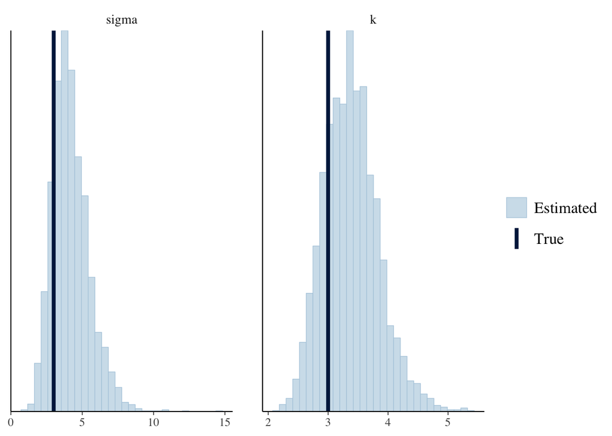

```r
true_sigma_k <- c(sigma, k)
mcmc_recover_hist(posterior_sigma_k, true = true_sigma_k)
```

As we can see the MCMC can give us a good fit wit the true variables.

### b. In two or three sentences, discuss the strengths and weaknesses of the model. How might the model be expanded?

The tutorial is very clear and well designed. One improvement i want to have a try is to do the extreme value analysis beyond the generalized Pareto distribution (GPD).

There is a distribution called generalized extreme value (GEV) distribution which is a family of continuous probability distributions developed within extreme value theory. To see more in https://en.wikipedia.org/wiki/Generalized_extreme_value_distribution.